# Personal Loan Campaign Modeling Solution

## Insight

```
Age,Experience,Zip are insignificant
Income and high credit average are high for ppl who take the loan
```

```python
data.groupby(['Personal Loan']).mean()
```

| Personal Loan | Income | CCAvg | Mortgage | Experience | Age |
| --- | --- | --- | --- | --- | --- |
| 0 | 66.237389 | 1.729009 | 51.789381 | 20.132301 | 45.367257 |
| 1 | 144.745833 | 3.905354 | 100.845833 | 19.843750 | 45.066667 |

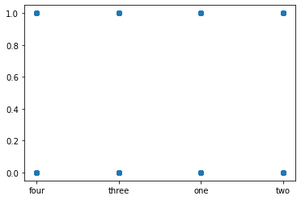

```python
#pd.crosstab(df["Family"],df["Personal Loan"],normalize='columns')
plt.scatter(df["Family"],df["Personal Loan"])
plt.show()
#"Family" doesnt have significant effect on "Personal Loan"
```

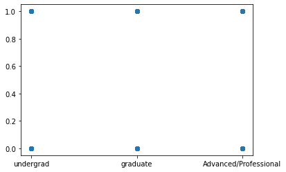

```python
plt.scatter(df["Education"],df["Personal Loan"])
plt.show()
#"Education" doesnt have significant effect on "Personal Loan"
```

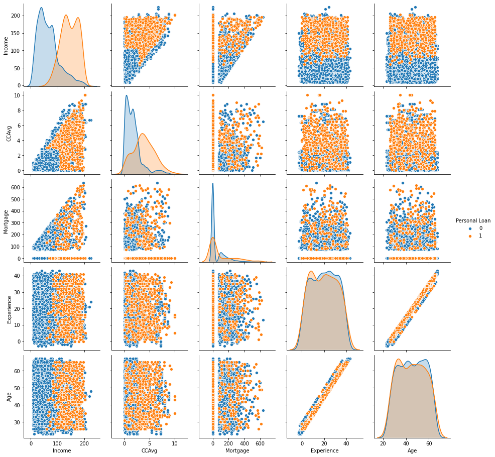

```python
sns.pairplot(data,hue='Personal Loan')
```

# Insight:

```
Age and Experince have positive correlation
"Income" positive skewered towards right
"CCAvg" positive skewered towards right
"Mortgage" positive skewered towards right
```

```python
#Correcting negative Experience

negativeExperience=df[df['Experience'] < 0]
positiveExperience=df[df['Experience'] > 0]

#need to watch this negativeExperience
print ("Total number of ppl with negative experience:",negativeExperience['Experience'].count())
print("People having negative experinece:\n",negativeExperience['Experience'].value_counts())

#Replace negative experience value with median value of the positive experience of the same educationa nd age.

for id in negativeExperience['ID']:
    age = df.loc[np.where(df['ID']==id)]["Age"].tolist()[0]
    education= df.loc[np.where(df['ID']==id)]["Education"].tolist()[0]
    df_possitiveExperience = positiveExperience[(positiveExperience['Age'] == age) & (positiveExperience['Education'] == education)]
    if df_possitiveExperience.empty :
        df_negative_Experience = negativeExperience[(negativeExperience['Age'] == age) & (negativeExperience['Education'] == education)]
        exp = round(df_negative_Experience['Experience'].median())
    else:
        exp = round(df_possitiveExperience['Experience'].median())
    df.loc[df.loc[np.where(df['ID']==id)].index, 'Experience'] = abs(exp)
```

```
Total number of ppl with negative experience: 52
People having negative experinece:
 -1    33
-2    15
-3     4
Name: Experience, dtype: int64
```

```python
# After replacing values
df[df['Experience'] < 0]['Experience'].count()
```

```
0
```

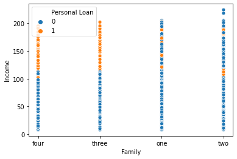

```python
sns.scatterplot(data=df, x="Family", y="Income",hue="Personal Loan")
```

## Observation

Family with 3 and 4 members with income more than 115K have taken loan.

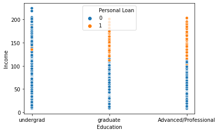

```python
sns.scatterplot(data=df, x="Education", y="Income",hue="Personal Loan")
```

## Observation

graduate and Advanced/Professional with income over 110K have taken the loan

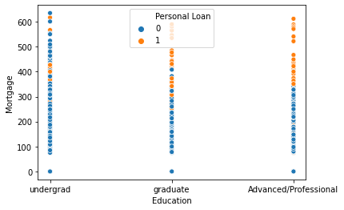

```python
#sns.scatterplot(data=df, x="Mortgage", y="Income",hue="Personal Loan")
sns.scatterplot(data=df, y="Mortgage", x="Education",hue="Personal Loan")
```

majority of undergards dint take a loan

Graduate and Advanced/Professional with mortgage 300K-650K have taken loan

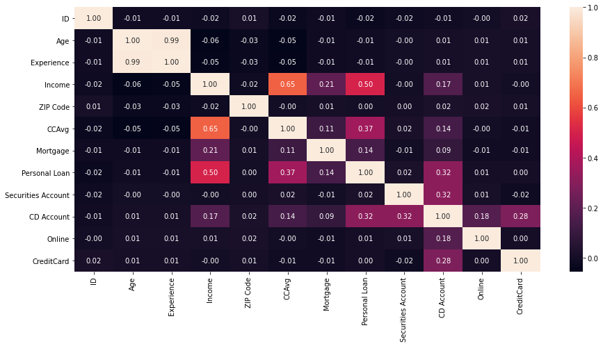

```python
plt.figure(figsize = (15,7))
sns.heatmap(df.corr(),annot=True, fmt='.2f')
```

## Observation

`From the above map "Id and Zip" are irrelevant to the model better to remove "ID" and "Zip"

"Age" and "Experience" have high correlation.

"PErsonal loan","income","CCavg" have some correlation

"creditcard" "securities Account" "CD Account" have some correlation

Building a model with and without "Experience" to compare and study`

## Model building Data

```python
df = df.drop(['ID','ZIP Code'], axis=1)
df.head(1)
```

|  | Age | Experience | Income | Family | CCAvg | Education | Mortgage | Personal Loan | Securities Account | CD Account | Online | CreditCard |
| --- | --- | --- | --- | --- | --- | --- | --- | --- | --- | --- | --- | --- |
| 0 | 25 | 1 | 49 | four | 1.6 | undergrad | 0 | 0 | 1 | 0 | 0 | 0 |

```python
#Personal loan with experience
PL_E=df
#Personal loan without experience
PL_WE=df.drop(['Experience'], axis=1)
```

```python
#Dataframe with Experience
X_Expr = PL_E.drop('Personal Loan', axis=1)
Y_Expr = PL_E['Personal Loan'].astype('category')
```

```python
#Dataframe without Experience
X_WExpr = PL_WE.drop('Personal Loan', axis=1)
Y_WExpr = PL_WE['Personal Loan'].astype('category')
```

```python
#Convert categorical vriables to dummy variables
X_Expr = pd.get_dummies(X_Expr, drop_first=True)
X_WExpr = pd.get_dummies(X_WExpr, drop_first=True)
```

# Logistic Regression

1. Split the data into training and test set in the ratio of 70:30 respectively (5 marks)

```python
##Split into training and test set With Experience
from sklearn.model_selection import train_test_split

X_Expr_train, X_Expr_test, Y_Expr_train, Y_Expr_test = train_test_split(X_Expr, Y_Expr, test_size=0.30,random_state=1)
print('x train data',X_Expr_train.shape)
print('y train data',Y_Expr_train.shape)
print('x test data',X_Expr_test.shape)
print('y test data',Y_Expr_test.shape)
```

```
x train data (3500, 14)
y train data (3500,)
x test data (1500, 14)
y test data (1500,)
```

## With Experience

```
LogisticRegression(fit_intercept=False, random_state=4294967295)
```

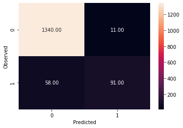

```
None
```

```python
from sklearn.metrics import confusion_matrix, recall_score, precision_score, f1_score, roc_auc_score,accuracy_score
from sklearn.linear_model import LogisticRegression

logreg = LogisticRegression(random_state=4294967295,fit_intercept=False)
logreg.fit(X_Expr_train, Y_Expr_train)                    # fit the model on train data
print(logreg , '\n')

y_Expr_predict = logreg.predict(X_Expr_test)
logreg_X_Expr_score=logreg.score(X_Expr_test,Y_Expr_test)
logreg_X_Expr_accuracy=accuracy_score(Y_Expr_test,y_Expr_predict)
print(draw_cm(Y_Expr_test,y_Expr_predict))
```

```python
# Observe the predicted and observed classes in a dataframe.
z = X_Expr_test.copy()
z['Observed Personal Status'] = Y_Expr_test
z['Predicted Personal Status'] = y_Expr_predict
z.head()
```

|  | Age | Experience | Income | CCAvg | Mortgage | Securities Account | CD Account | Online | CreditCard | Family_one | Family_three | Family_two | Education_graduate | Education_undergrad | Observed Personal Status | Predicted Personal Status |
| --- | --- | --- | --- | --- | --- | --- | --- | --- | --- | --- | --- | --- | --- | --- | --- | --- |
| 2764 | 31 | 5 | 84 | 2.9 | 105 | 0 | 0 | 0 | 1 | 1 | 0 | 0 | 0 | 0 | 0 | 0 |
| 4767 | 35 | 9 | 45 | 0.9 | 101 | 1 | 0 | 0 | 0 | 0 | 1 | 0 | 0 | 1 | 0 | 0 |
| 3814 | 34 | 9 | 35 | 1.3 | 0 | 0 | 0 | 0 | 0 | 0 | 1 | 0 | 0 | 1 | 0 | 0 |
| 3499 | 49 | 23 | 114 | 0.3 | 286 | 0 | 0 | 1 | 0 | 1 | 0 | 0 | 0 | 1 | 0 | 0 |
| 2735 | 36 | 12 | 70 | 2.6 | 165 | 0 | 0 | 1 | 0 | 0 | 1 | 0 | 1 | 0 | 0 | 0 |

```
Trainig accuracy 0.954

Testing accuracy 0.954

Confusion Matrix
```

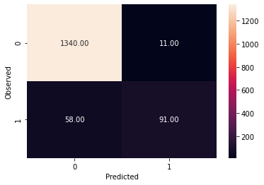

```
None

Recall: 0.610738255033557

Precision: 0.8921568627450981

F1 Score: 0.7250996015936254

Roc Auc Score: 0.801298069041575
```

```python
print("Trainig accuracy",logreg.score(X_Expr_test,Y_Expr_test))
print()
print("Testing accuracy",logreg.score(X_Expr_test,Y_Expr_test))
print()
print('Confusion Matrix')
print(draw_cm(Y_Expr_test,y_Expr_predict))
print()
print("Recall:",recall_score(Y_Expr_test,y_Expr_predict))
print()
print("Precision:",precision_score(Y_Expr_test,y_Expr_predict))
print()
print("F1 Score:",f1_score(Y_Expr_test,y_Expr_predict))
print()
print("Roc Auc Score:",roc_auc_score(Y_Expr_test,y_Expr_predict))
```

```python
## Feature Importance or Coefficients
fi = pd.DataFrame()
fi['Col'] = X_Expr_train.columns
fi['Coeff'] = np.round(abs(logreg.coef_[0]),2)
fi.sort_values(by='Coeff',ascending=False)
```

|  | Col | Coeff |
| --- | --- | --- |
| 13 | Education_undergrad | 4.00 |
| 6 | CD Account | 2.41 |
| 11 | Family_two | 1.46 |
| 9 | Family_one | 1.42 |
| 10 | Family_three | 0.89 |
| 8 | CreditCard | 0.58 |
| 7 | Online | 0.39 |
| 0 | Age | 0.28 |
| 1 | Experience | 0.28 |
| 5 | Securities Account | 0.23 |
| 3 | CCAvg | 0.18 |
| 12 | Education_graduate | 0.15 |
| 2 | Income | 0.06 |
| 4 | Mortgage | 0.00 |

## Without Experience

```python
X_WExpr_train, X_WExpr_test, Y_WExpr_train, Y_WExpr_test = train_test_split(X_WExpr, Y_WExpr, test_size=0.30,random_state=1)
print('x train data',X_WExpr_train.shape)
print('y train data',Y_WExpr_train.shape)
print('x test data',X_WExpr_test.shape)
print('y test data',Y_WExpr_test.shape)
```

```
x train data (3500, 13)
y train data (3500,)
x test data (1500, 13)
y test data (1500,)
```

```
LogisticRegression(fit_intercept=False, random_state=4294967295)
```

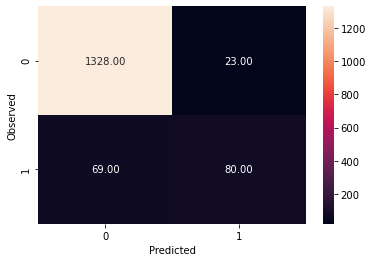

```
None
```

```python
logreg_we = LogisticRegression(random_state=4294967295,fit_intercept=False)
logreg_we.fit(X_WExpr_train, Y_WExpr_train)                    # fit the model on train data
print(logreg_we , '\n')

y_WExpr_predict = logreg_we.predict(X_WExpr_test)
logreg_X_WExpr_score=logreg_we.score(X_WExpr_test,Y_WExpr_test)
logreg_X_WExpr_accuracy=accuracy_score(Y_WExpr_test,y_WExpr_predict)
print(draw_cm(Y_WExpr_test,y_WExpr_predict))
```

```python
# Observe the predicted and observed classes in a dataframe.
z = X_WExpr_test.copy()
z['Observed Personal Status'] = Y_WExpr_test
z['Predicted Personal Status'] = y_WExpr_predict
z.head()
```

|  | Age | Income | CCAvg | Mortgage | Securities Account | CD Account | Online | CreditCard | Family_one | Family_three | Family_two | Education_graduate | Education_undergrad | Observed Personal Status | Predicted Personal Status |
| --- | --- | --- | --- | --- | --- | --- | --- | --- | --- | --- | --- | --- | --- | --- | --- |
| 2764 | 31 | 84 | 2.9 | 105 | 0 | 0 | 0 | 1 | 1 | 0 | 0 | 0 | 0 | 0 | 0 |
| 4767 | 35 | 45 | 0.9 | 101 | 1 | 0 | 0 | 0 | 0 | 1 | 0 | 0 | 1 | 0 | 0 |
| 3814 | 34 | 35 | 1.3 | 0 | 0 | 0 | 0 | 0 | 0 | 1 | 0 | 0 | 1 | 0 | 0 |
| 3499 | 49 | 114 | 0.3 | 286 | 0 | 0 | 1 | 0 | 1 | 0 | 0 | 0 | 1 | 0 | 0 |
| 2735 | 36 | 70 | 2.6 | 165 | 0 | 0 | 1 | 0 | 0 | 1 | 0 | 1 | 0 | 0 | 0 |

```
Trainig accuracy 0.9386666666666666

Testing accuracy 0.9386666666666666

Confusion Matrix
```

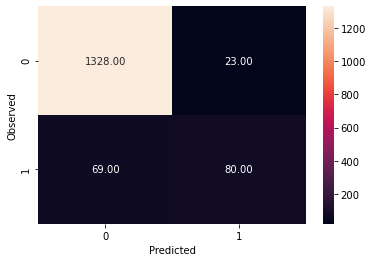

```
None

Recall: 0.5369127516778524

Precision: 0.7766990291262136

F1 Score: 0.6349206349206349

Roc Auc Score: 0.7599441626635006
```

```python
print("Trainig accuracy",logreg_we.score(X_WExpr_test,Y_WExpr_test))
print()
print("Testing accuracy",logreg_we.score(X_WExpr_test,Y_WExpr_test))
print()
print('Confusion Matrix')
print(draw_cm(Y_WExpr_test,y_WExpr_predict))
print()
print("Recall:",recall_score(Y_WExpr_test,y_WExpr_predict))
print()
print("Precision:",precision_score(Y_WExpr_test,y_WExpr_predict))
print()
print("F1 Score:",f1_score(Y_WExpr_test,y_WExpr_predict))
print()
print("Roc Auc Score:",roc_auc_score(Y_WExpr_test,y_WExpr_predict))
```

```python
## function to get confusion matrix in a proper format
def draw_cm( actual, predicted ):
    cm = confusion_matrix( actual, predicted)
    sns.heatmap(cm, annot=True,  fmt='.2f', xticklabels = [0,1] , yticklabels = [0,1] )
    plt.ylabel('Observed')
    plt.xlabel('Predicted')
    plt.show()
```

```python
## Feature Importance or Coefficients
fi = pd.DataFrame()
fi['Col'] = X_WExpr_train.columns
fi['Coeff'] = np.round(abs(logreg_we.coef_[0]),2)
fi.sort_values(by='Coeff',ascending=False)
```

|  | Col | Coeff |
| --- | --- | --- |
| 12 | Education_undergrad | 3.54 |
| 5 | CD Account | 3.06 |
| 8 | Family_one | 1.79 |
| 10 | Family_two | 1.66 |
| 7 | CreditCard | 1.04 |
| 11 | Education_graduate | 1.02 |
| 6 | Online | 0.83 |
| 4 | Securities Account | 0.58 |
| 2 | CCAvg | 0.15 |
| 0 | Age | 0.09 |
| 9 | Family_three | 0.09 |
| 1 | Income | 0.04 |
| 3 | Mortgage | 0.00 |

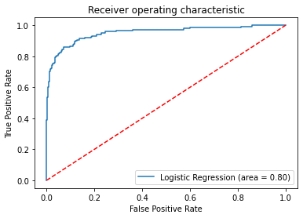

```python
# !pip install yellowbrick

# Additional

#AUC ROC curve
from sklearn.metrics import roc_auc_score
from sklearn.metrics import roc_curve

logit_roc_auc = roc_auc_score(Y_Expr_test, logreg.predict(X_Expr_test))
fpr, tpr, thresholds = roc_curve(Y_Expr_test, logreg.predict_proba(X_Expr_test)[:,1])
plt.figure()
plt.plot(fpr, tpr, label='Logistic Regression (area = %0.2f)' % logit_roc_auc)
plt.plot([0, 1], [0, 1],'r--')
plt.xlabel('False Positive Rate')
plt.ylabel('True Positive Rate')
plt.title('Receiver operating characteristic')
plt.legend(loc="lower right")
plt.savefig('Log_ROC')
plt.show()
```

# Business Insight

##### Confusion Matrix:

*True Positive (observed=1,predicted=1):*

Predicted that custometer will purchase a personal loan and the customer was liable for loan

*False Positive (observed=0,predicted=1):*

Predicted that custometer will purchase a personal loan and the customer was not liable for loan

*True Negative (observed=0,predicted=0):*

Predicted that custometer will not purchase a personal loan and the customer was not liable for loan

*False Negative (observed=1,predicted=0):*

Predicted that custometer will not purchase a personal loan and the customer was liable for loan

##### Important features

Mortgage has coefficients value as 0 so these feature doesn't help model in predicting target variable. Education_undergrad,CD Account,Family_two,Family_one are the top features based on the coefficient

###### Observations for Model With Experience and Metrics

From the two models its evident that the accuracy and Precision are better for the model with "Experience"

Significantly less false positive

Better knowledge about which group likely to accept and reject loan offer.

Better campaigning approach required for family with "one" and "two" family member and pursue them to accept the loan

Better campaigning approach required for undergrad customers and pursue them to accept the loan